# Making ekonometrics more meaningful (RR approach)

Tomasz Przechlewski

25 października 2019

## Reproducible research idea

Abandoning the habit of secrecy in favor of process transparency and peer review was the crucial step by which alchemy became chemistry. Eric S. Raymond, E. S. The art of UNIX programming: Addison-Wesley.

Replicability vs Reproducibility

Hot topic: google: reproducible research = 158000

**Replicability**: independent experiment targetting the same question will produce a result consistent with the original study.

**Reproducibility**: ability to repeat the experiment with exactly the same outcome as originally reported [description of method/code/data is needed to do so].

Computational science is facing a credibility crisis: it’s impossible to verify most of the computational results presented at conferences and in papers today. (Donoho D. et al 2009)

## Australopithecus (Current practices)

- Enter data in Excel/OOCalc to clean and/or make explanatory analysis.
  - Use Excel for data cleaning & descriptive statistics
  - Excel handles missing data inconsistently and sometimes incorrectly
  - Many common functions are poor or missing in Excel
- Import data from Spreadsheet into SPSS/SAS/Stata for serious analysis
- Use SPSS/SAS/Stata in point-and-click mode to run serious statistical analyses.
- Prepare report/paper: copy and paste output to Word/OpenOffice, add description.
- Send to publisher (repeat 1–4 if returned for revision).

Problems

- Tedious/time-wasting/costly.
- Even small data/method change requires extensive recomputation effort/careful report/paper revision and update.
- Error-prone: difficult to record/remember a ‘click history’.

Famous example: Reinhart and Rogoff controversy Countries very high GDP–debt ratio suffer from low growth. However the study suffers serious but easy identifiable flaws which were discovered when RR published the dataset they used in their analysis (cf Growth_in_a_Time_of_Debt)

## Homo habilis (Enhanced current practices)

- Abandon spreadsheets.
- Abandon point-and-click mode. Use statistical scripting languages and run program/scripts.

Benefits

Improved: reliability, transparency, automation, maintanability. Lower costs (in the long run).

Solves 1–2 but not 3–4.

Problems: Steeper learning curve. Perhaps higher costs in short run. Duplication of effort (or mess if scripts/programs are poorly documented).

## Homo Erectus (Literate statistical programming)

Literate programming concept: Code and description in one document. Create software as works of literature, by embedding source code inside descriptive text, rather than the reverse (as in most programming languages), in an order that is convenient for human readers.

A program is like a WEB tangled and weaved (turned into a document), with relations and connections in the program parts. We express a program as a *web of ideas*. WEB is a combination of – a document formatting language and – a program language.

General idea of Literate statistical programming mimics Knuth’s WEB system.

Solves 1–4.

## LSP: Benefits/Problems/Tools

- Reliability: Easier to find/fix bugs. The results produced will not change when recomputed (in theory at least).
- Efficiency: Reuse allows to avoid duplication of effort (Payoff in the long run.)
- Transparency: increased citation rate, broader impact, improved institutional memory
- Institutional memory is a collective set of facts, concepts, experiences and know-how held by a group of people.
- Flexibility: When you don’t ‘point-and-click’ you gain many new analytic options.

Problems of LSP: Many incl. costs and learning curve

Tools:

- Document formatting language: LaTeX (not recommended) or Markdown (or many others, ie. orgmode). LaTeX is a word processor/a document markup language. Markdown: lightweight document markup language based on email text formatting. Easy to write, read and publish as-is.
- Program language: R

## Interlude: Github for the uninitiated

The basic idea is that instead of manually registerging changes one has made to data, documents etc, one can use software to help him manage the whole process. Such software is called **Version Control Systems** or VCS

VCS not only manages content, registering each modification of it, but control access to the content as well. Thus many individuals can work on common project (compare this to common scenario of mailing spreadsheets to each other–higly inefficient at least)

There are highly reliable and publicly available VCS services and GitHub is the most popular of them.

GitHub is owned by Microsoft (do not use if you boycott MS :-))

I use GitHub as an educational tool: to distribute learning content to my students and to store content they produce for me (ie projects)

The free GitHub account is public. It is OK for me. If it is not OK for you, you can buy a license for commercial account or do not use GitHub.

## Linear Regression of the Janka Hardness Data

First, we load the data into a dataframe from CSV file:

```r
janka = read.csv("janka.csv", header = TRUE, sep=";")
```

The `header=TRUE` option tells R to use the first line as column names Try typing just `janka` into the command line to see the raw data:

```r
janka
```

```
##    dens hardness
## 1  24.7      484
## 2  24.8      427
## 3  27.3      413
## 4  28.4      517
## 5  28.4      549
## 6  29.0      648
## 7  30.3      587
## 8  32.7      704
## 9  35.6      979
## 10 38.5      914
## 11 38.8     1070
## 12 39.3     1020
## 13 39.4     1210
## 14 39.9      989
```

[output cut: 22 more lines]

A scatterplot of the data is simple in R

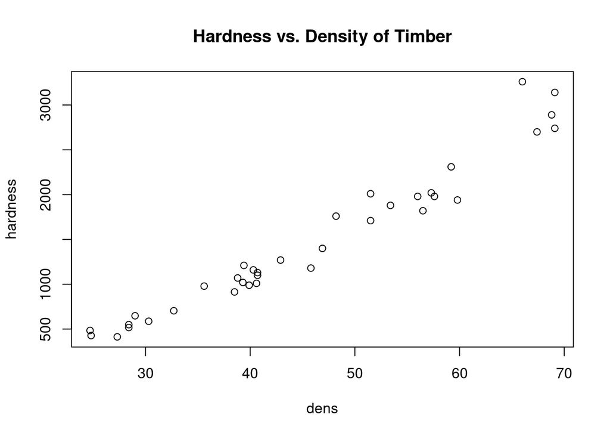

```r
plot(janka, main = "Hardness vs. Density of Timber")
```

This is the same as calling the following command (but notice the axes are labeled different)

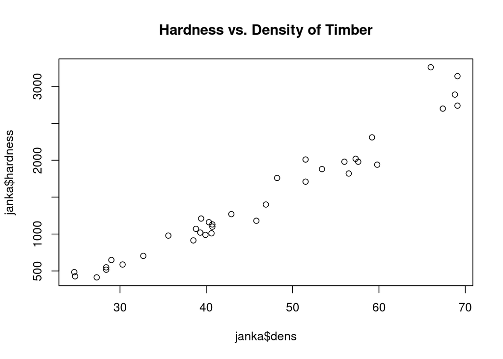

```r
plot(janka$hardness ~ janka$dens, main = "Hardness vs. Density of Timber")
```

The `y ~ x` means y is the dependent variable and x is the independent variable. The `lm` command stands for “linear model” and will fit a linear regression to paired data. It uses the same `y ~ x` syntax.

```r
janka.model = lm(hardness ~ dens, data = janka)
```

The output of `lm` is an object with lots of information about the linear regression fit. Type the following command to see what variables it contains.

```r
names(janka.model)
```

```
##  [1] "coefficients"  "residuals"     "effects"       "rank"
##  [5] "fitted.values" "assign"        "qr"            "df.residual"
##  [9] "xlevels"       "call"          "terms"         "model"
```

The first item to look at is the “coefficients” this is the intercept (alpha) and slope (beta)

```r
janka.model$coefficients
```

```
## (Intercept)        dens
## -1160.49970    57.50667
```

The command “abline” will add a line to the plot with a certain intercept a (first parameter) and slope b (second parameter)

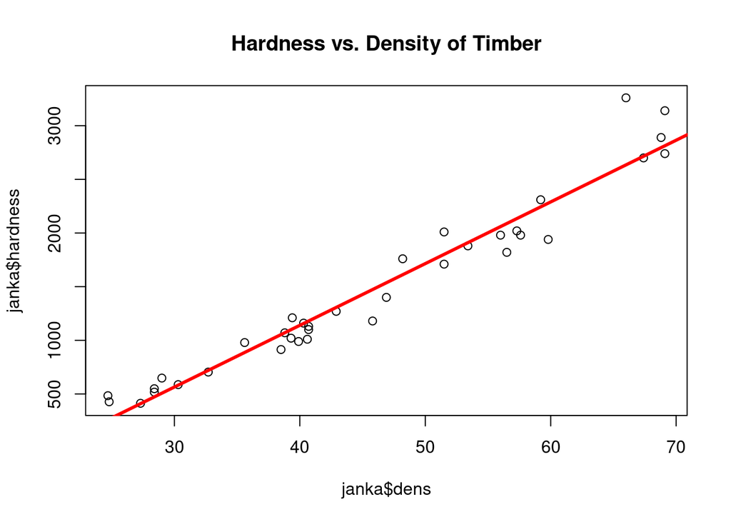

```r
plot(janka$hardness ~ janka$dens, main = "Hardness vs. Density of Timber")
abline(janka.model$coefficients[1], janka.model$coefficients[2], col = "red", lwd = 3)
```

The abline command is smart enough to know when you pass it a regression fit. The above command can be simplified like so:

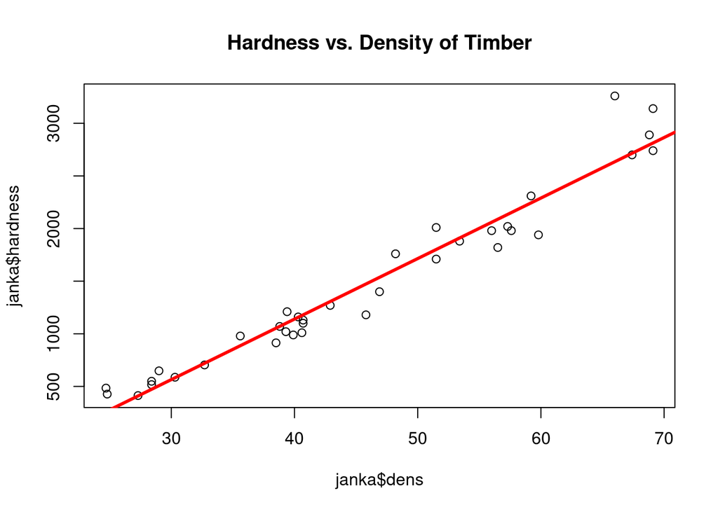

```r
plot(janka$hardness ~ janka$dens, main = "Hardness vs. Density of Timber")
abline(janka.model, col = "red", lwd = 3)
```

Hypothesis testing of the intercept and slope parameters is easy in R. Here the null hypothesis is that the intercept (or respectively, slope) is equal to zero. The alternative hypothesis is that the intercept (respectively, slope) is not equal to zero. The p-values you see in the table are for these two hypotheses.

```r
summary(janka.model)
```

```
##
## Call:
## lm(formula = hardness ~ dens, data = janka)
##
## Residuals:
##     Min      1Q  Median      3Q     Max
## -338.40  -96.98  -15.71   92.71  625.06
##
## Coefficients:
##              Estimate Std. Error t value Pr(>|t|)
## (Intercept) -1160.500    108.580  -10.69 2.07e-12 ***
## dens           57.507      2.279   25.24  < 2e-16 ***
## ---
## Signif. codes:  0 '***' 0.001 '**' 0.01 '*' 0.05 '.' 0.1 ' ' 1
##
## Residual standard error: 183.1 on 34 degrees of freedom
## Multiple R-squared:  0.9493, Adjusted R-squared:  0.9478
## F-statistic:   637 on 1 and 34 DF,  p-value: < 2.2e-16
```

The next thing we can look at is the residuals between the data and the model For the hypothesis testing assumptions to be valid, these should be roughly Gaussian:

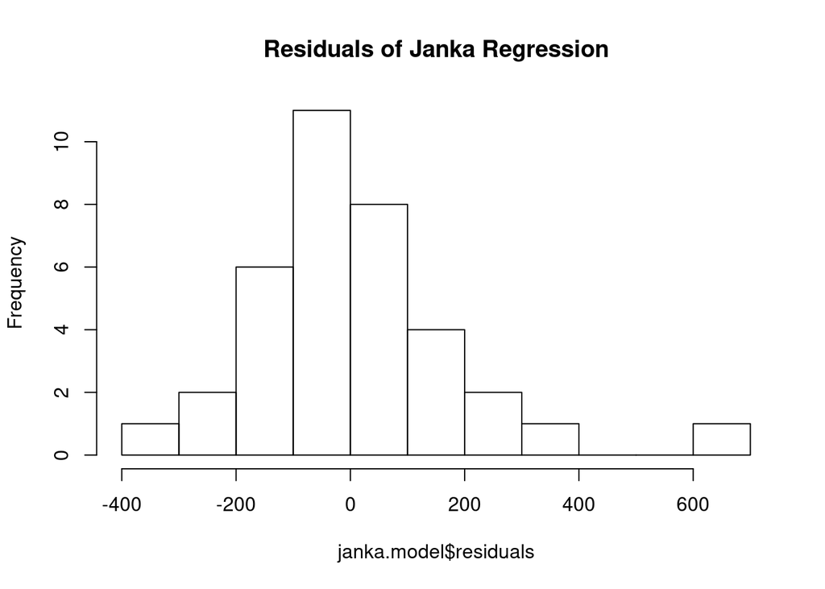

```r
hist(janka.model$residuals, main = "Residuals of Janka Regression")
```

Another way to visualize if the residuals seem Gaussian distributed is a Q-Q plot, which stands for “Quantile-Quantile” plot. It plots the empirical quantiles of the data (y axis) versus the theoretical quantiles of a Gaussian distribution (x axis). If the data comes from a Gaussian, the points should lie on a 45 degree line. See the Wikipedia page for more info:

https://en.wikipedia.org/wiki/Q-Q_plot

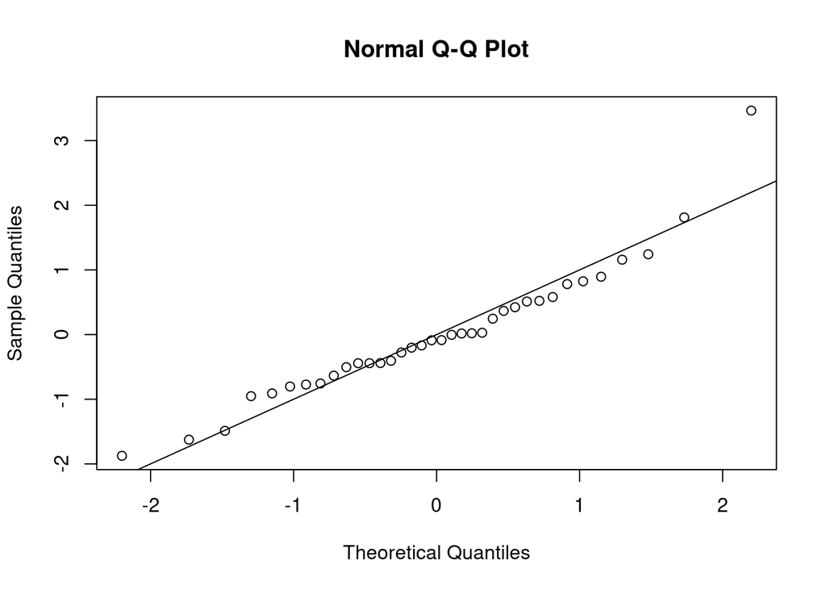

```r
qqnorm(janka.model$residuals / sd(janka.model$residuals))
abline(0, 1)
```

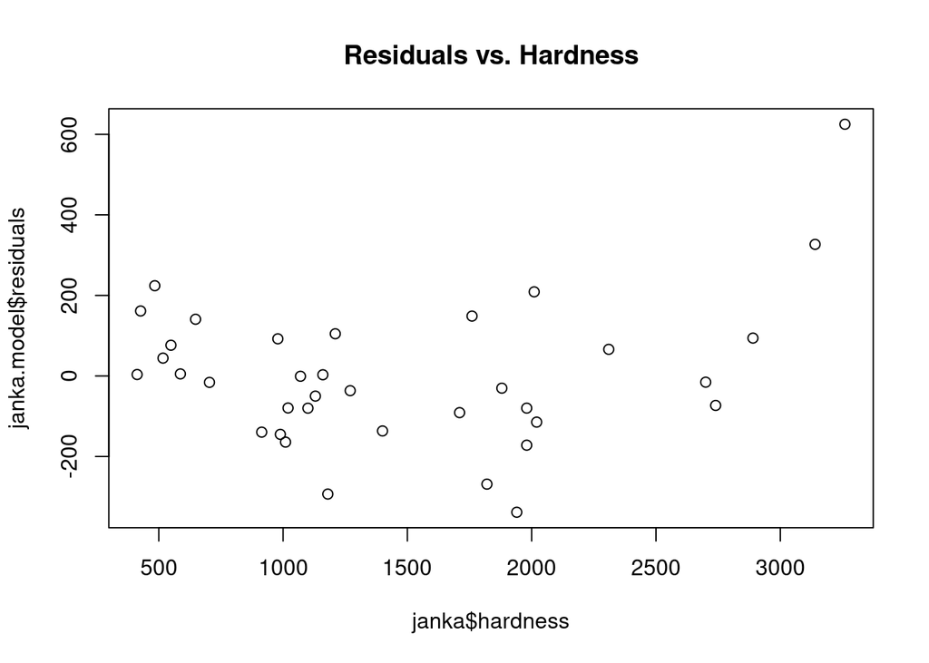

```r
plot(janka.model$residuals ~ janka$hardness, main = "Residuals vs. Hardness")
```

## Another example: Malbork Castle

First, we load the data into a dataframe:

```r
dane <- read.csv(file= "MZM.csv", header=T, sep=";");
```

Inspect the data

```r
str(dane)
```

```
## 'data.frame':    51 obs. of  4 variables:
##  $ data       : Factor w/ 51 levels "2015-01-01","2015-02-01",..: 1 2 3 4 5 6 7 8 9 10 ...
##  $ razem      : int  3278 4149 4623 13083 68485 66199 105843 95255 28021 13532 ...
##  $ zagraniczni: int  2144 1000 2128 5293 17384 18831 27809 28109 17853 8876 ...
##  $ krajowi    : num  5422 5149 6751 18376 85869 ...
```

```r
# show top
head(dane)
```

```
##         data razem zagraniczni krajowi
## 1 2015-01-01  3278        2144    5422
## 2 2015-02-01  4149        1000    5149
## 3 2015-03-01  4623        2128    6751
## 4 2015-04-01 13083        5293   18376
## 5 2015-05-01 68485       17384   85869
## 6 2015-06-01 66199       18831   85030
```

```r
# show length
length(dane)
```

```
## [1] 4
```

Load required library (`forecast`). Transform data (column) on total number of visitors into object of type ts (time-series)

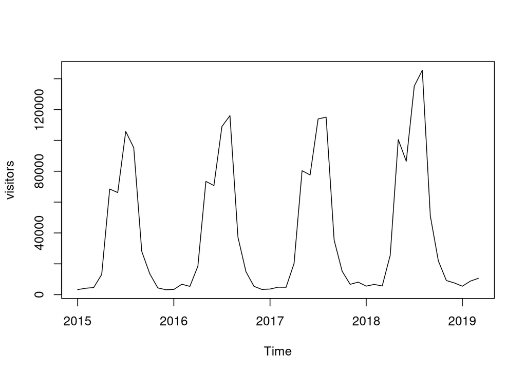

```r
library(forecast)

visitors <- ts(dane$razem, frequency=12, start = c(2015, 01), end = c(2019, 03))
# Plot the data
plot(visitors)
```

```r
# show start/end/frequency of data
start(visitors)
```

```
## [1] 2015    1
```

```r
end(visitors)
```

```
## [1] 2019    3
```

```r
frequency(visitors)
```

```
## [1] 12
```

```r
## test/learn sets (not used)
visitors.learn <- window (visitors, end = c(2018, 1))
start (visitors.learn)
```

```
## [1] 2015    1
```

```r
end(visitors.learn)
```

```
## [1] 2018    1
```

```r
length(visitors.learn)
```

```
## [1] 37
```

```r
visitors.test <- window(visitors, start= c(2019, 1))
start(visitors.test)
```

```
## [1] 2019    1
```

```r
end(visitors.test)
```

```
## [1] 2019    3
```

```r
length(visitors.test)
```

```
## [1] 3
```

Linear trend

```r
mzm.trend <- tslm(visitors ~ trend)

summary(mzm.trend )
```

```
##
## Call:
## tslm(formula = visitors ~ trend)
##
## Residuals:
##    Min     1Q Median     3Q    Max
## -37469 -33292 -22617  34646 103400
##
## Coefficients:
##             Estimate Std. Error t value Pr(>|t|)
## (Intercept)  34404.7    12367.1   2.782  0.00765 **
## trend          174.4      413.9   0.421  0.67533
## ---
## Signif. codes:  0 '***' 0.001 '**' 0.01 '*' 0.05 '.' 0.1 ' ' 1
##
## Residual standard error: 43510 on 49 degrees of freedom
## Multiple R-squared:  0.00361,    Adjusted R-squared:  -0.01672
## F-statistic: 0.1776 on 1 and 49 DF,  p-value: 0.6753
```

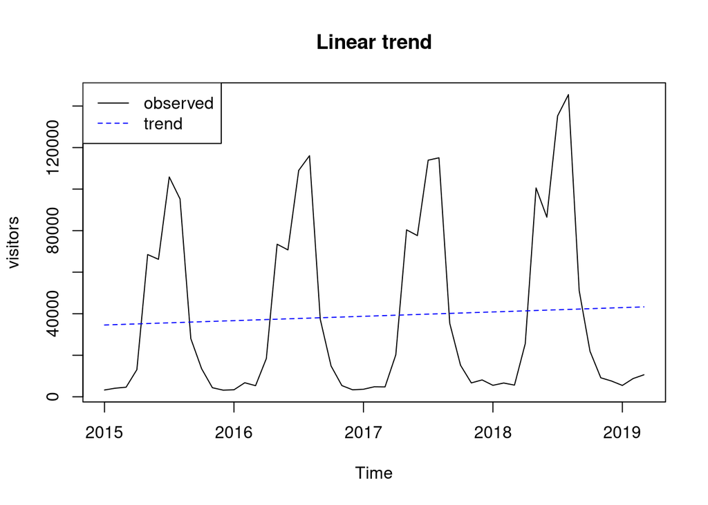

```r
plot(visitors, main="Linear trend")
lines(fitted(mzm.trend), col="blue", lty=2)
legend("topleft", legend=c("observed", "trend"), col=c("black", "blue"), lty=c(1,2))
```

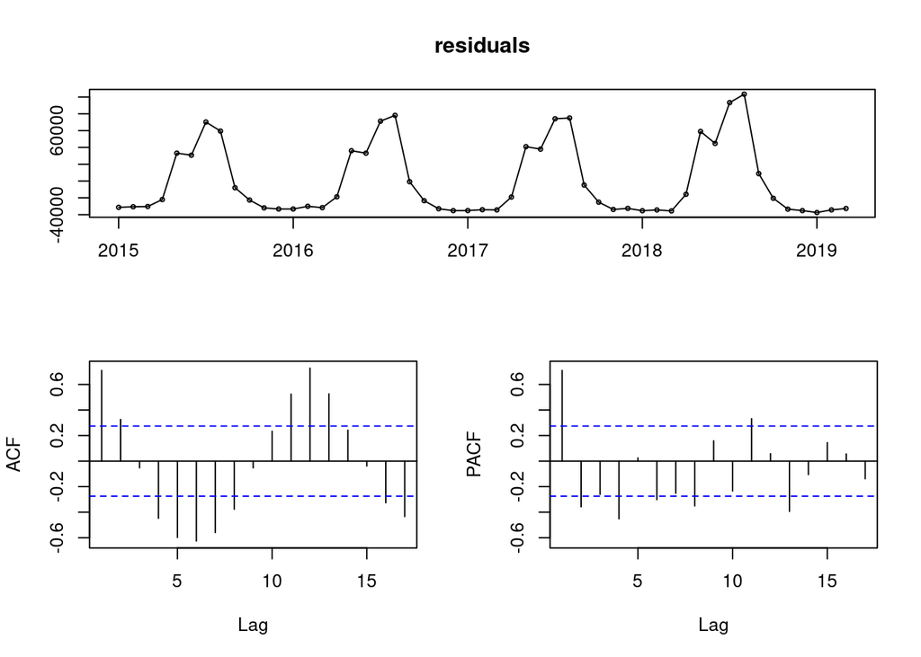

```r
tsdisplay(residuals(mzm.trend), main="residuals")
```

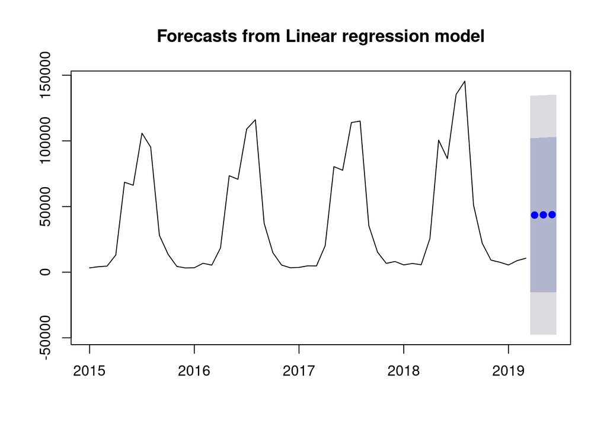

```r
plot(forecast(mzm.trend, h=3))
```

Linear trend with seasonality

```r
mzm.trend.season <- tslm(visitors ~ trend + season)

summary(mzm.trend.season )
```

```
##
## Call:
## tslm(formula = visitors ~ trend + season)
##
## Residuals:
##    Min     1Q Median     3Q    Max
## -16360  -3824   -794   3377  21154
##
## Coefficients:
##              Estimate Std. Error t value Pr(>|t|)
## (Intercept)  -4563.19    3470.43  -1.315  0.19643
## trend          353.06      65.76   5.369 4.18e-06 ***
## season2       1621.34    4322.78   0.375  0.70969
## season3       1230.29    4324.28   0.285  0.77757
## season4      16139.22    4588.71   3.517  0.00115 **
## season5      77161.66    4586.35  16.824  < 2e-16 ***
## season6      71352.11    4584.94  15.562  < 2e-16 ***
## season7     111749.55    4584.47  24.376  < 2e-16 ***
## season8     113353.49    4584.94  24.723  < 2e-16 ***
## season9      32964.69    4586.35   7.188 1.37e-08 ***
## season10     11052.63    4588.71   2.409  0.02097 *
## season11       738.33    4592.01   0.161  0.87311
## season12      -455.48    4596.24  -0.099  0.92158
## ---
## Signif. codes:  0 '***' 0.001 '**' 0.01 '*' 0.05 '.' 0.1 ' ' 1
##
## Residual standard error: 6834 on 38 degrees of freedom
## Multiple R-squared:  0.9809, Adjusted R-squared:  0.9749
## F-statistic:   163 on 12 and 38 DF,  p-value: < 2.2e-16
```

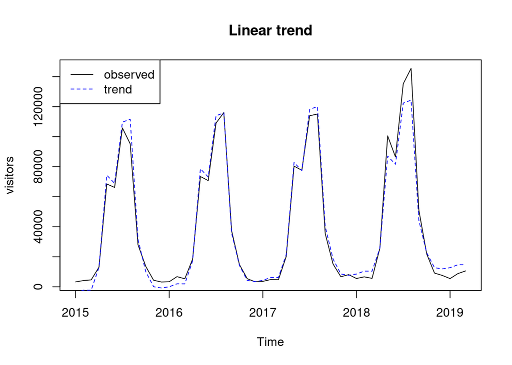

```r
plot(visitors, main="Linear trend", col="black")
lines(fitted(mzm.trend.season), col="blue", lty=2)
legend("topleft", legend=c("observed", "trend"), col=c("black", "blue"), lty=c(1,2))
```

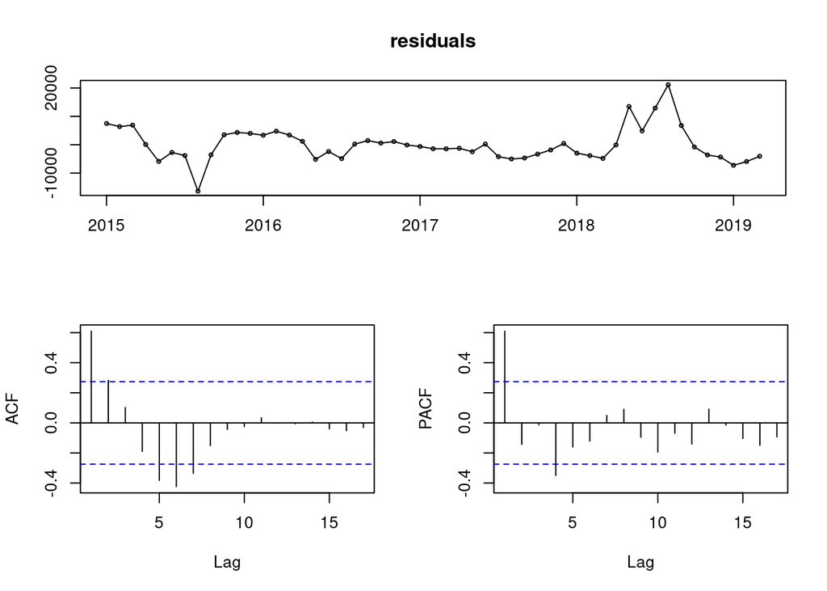

```r
tsdisplay(residuals(mzm.trend.season), main="residuals")
```

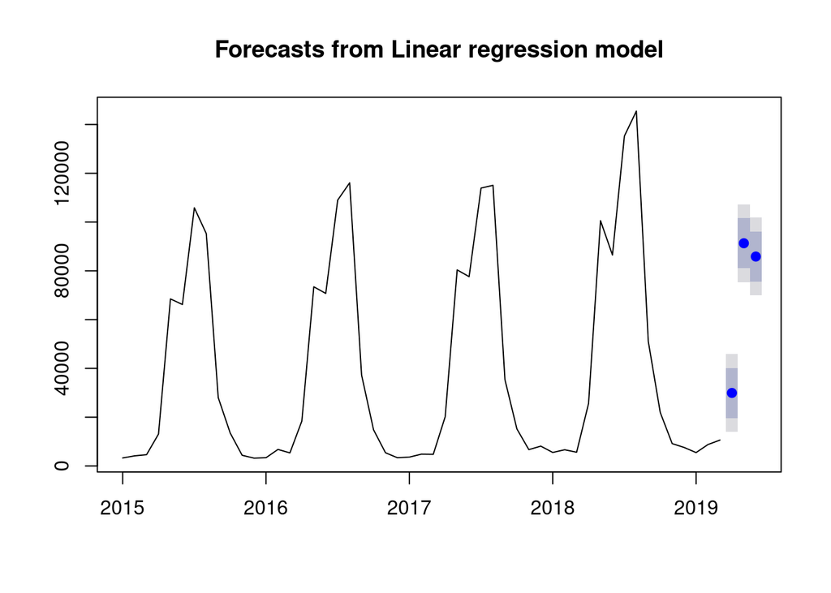

```r
plot(forecast(mzm.trend.season, h=3))
```

Squared trend with seasonality

```r
mzm.trend.season.sq <- tslm(visitors ~ season + poly(trend, raw=T, degree=2), lambda=0)
summary(mzm.trend.season.sq)
```

```
##
## Call:
## tslm(formula = visitors ~ season + poly(trend, raw = T, degree = 2),
##     lambda = 0)
##
## Residuals:
##      Min       1Q   Median       3Q      Max
## -0.27688 -0.07997  0.00452  0.06087  0.41297
##
## Coefficients:
##                                     Estimate Std. Error t value Pr(>|t|)
## (Intercept)                        8.088e+00  8.428e-02  95.957  < 2e-16
## season2                            3.601e-01  9.130e-02   3.944 0.000343
## season3                            3.230e-01  9.133e-02   3.537 0.001110
## season4                            1.578e+00  9.743e-02  16.199  < 2e-16
## season5                            3.012e+00  9.746e-02  30.910  < 2e-16
## season6                            2.936e+00  9.749e-02  30.113  < 2e-16
## season7                            3.356e+00  9.752e-02  34.413  < 2e-16
## season8                            3.352e+00  9.754e-02  34.369  < 2e-16
## season9                            2.192e+00  9.756e-02  22.467  < 2e-16
## season10                           1.342e+00  9.757e-02  13.759    4e-16
## season11                           3.702e-01  9.758e-02   3.794 0.000532
## season12                           1.591e-01  9.758e-02   1.630 0.111522
## poly(trend, raw = T, degree = 2)1 -2.428e-05  5.761e-03  -0.004 0.996660
## poly(trend, raw = T, degree = 2)2  2.658e-04  1.075e-04   2.472 0.018156
##
## (Intercept)                       ***
## season2                           ***
## season3                           **
## season4                           ***
## season5                           ***
## season6                           ***
## season7                           ***
## season8                           ***
## season9                           ***
## season10                          ***
## season11                          ***
## season12
## poly(trend, raw = T, degree = 2)1
## poly(trend, raw = T, degree = 2)2 *
## ---
## Signif. codes:  0 '***' 0.001 '**' 0.01 '*' 0.05 '.' 0.1 ' ' 1
##
## Residual standard error: 0.1443 on 37 degrees of freedom
## Multiple R-squared:      1,  Adjusted R-squared:      1
## F-statistic: 3.62e+11 on 13 and 37 DF,  p-value: < 2.2e-16
```

End of story

## Summary: New Tools

- R/Rstudio for computing and data visualization
- Github for enhancing team work
- markdown for reproducible research

**Learnig resources**

- [Rstudio](https://www.rstudio.com/resources/cheatsheets/)
- [Polish Main Statistical Office](https://stat.gov.pl/)
- Bank Danych Lokalnych (Local Data Bank)https://bdl.stat.gov.pl/BDL/start)
- [Eurostat (European Union Statistical Office)](https://ec.europa.eu/eurostat)
- [My github repository](https://github.com/hrpunio))
- [Tourism](http://appsso.eurostat.ec.europa.eu/nui/submitViewTableAction.do)
- [Coffee production/consumption](https://www.kaggle.com/sbajew/icos-crop-data)
- [Econometrics](https://justinmshea.github.io/wooldridge/)
- ScPoEconometrics